# centiBils: A unit for Investment Performance Analysis

## Tobias Brandt

[figure not shown]

## Abstract

Percentage Returns are the de-facto standard for Investment Performance Measurement. Yet they are not very well suited for multi-period performance evaluation. As an illustrative example, does the sequence (-30%, +40%) represent a positive or negative overall return? We review some of the problems with using percentage returns such as the lack of symmetry, lack of additivity and differences between the arithmetic and geometric means. We then introduce a new logarithmic unit modeled on the deciBel, tentatively called a centiBil, which addresses these shortcomings. Finally we conclude by using the centiBil to compare the performance of US Stocks, Bonds and Bills since 1927 and show how their use eases cross-period comparisons.

## Agenda

1. Problems with (Simple-)Returns
   - Returns are not symmetric
   - Returns are not (longitudinally) additive
   - The mean return doesn't represent the growth rate of the investment
2. Problems with existing logarithmic units
   - Neper
   - Bels (i.e. deciBels)

## Agenda (contd)

1. centiBils
   - Definition
   - Conversions
   - Standard Values
2. Applications
   - S&P 500 Returns since 1927

## Problems with Returns

### Returns are not symmetric

- You are probably aware that if your investment experiences a **-50%** return, you need a **+100%** just to break even again.
- This lack of symmetry makes it difficult to interpret sequences of returns.
- For example, does the sequence (-30%, +40%) represent an overall positive or negative return?

$$ r = (1 - \frac{30}{100})(1 + \frac{40}{100}) - 1 = -0.02 = -2\% $$

### Returns are not (longitudinally) additive

- As seen in the previous example, we have to add returns geometrically.

### The mean return doesn't represent the growth rate

$$ g = \mu - \frac{1}{2}\sigma^2 $$

### Example: US Asset Class Returns (since 1927)

```python
to_html_perc(us_returns_sample)
```

| Year | S&P 500 | 10-year T. Bond | 3-month T.Bill |
| --- | --- | --- | --- |
| 1928 | 43.81% | 0.84% | 3.08% |
| 1929 | -8.30% | 4.20% | 3.16% |
| 1930 | -25.12% | 4.54% | 4.55% |
| 1931 | -43.84% | -2.56% | 2.31% |
| 1932 | -8.64% | 8.79% | 1.07% |
| 2011 | 2.10% | 16.04% | 0.03% |
| 2012 | 15.89% | 2.97% | 0.05% |
| 2013 | 32.15% | -9.10% | 0.07% |
| 2014 | 13.52% | 10.75% | 0.05% |
| 2015 | 1.36% | 1.28% | 0.21% |

```python
to_html_perc(calc_metrics(returns))
```

|  | S&P 500 | 10-year T. Bond | 3-month T.Bill |
| --- | --- | --- | --- |
| Mean | 11.41% | 5.23% | 3.49% |
| Std Dev. | 19.82% | 7.79% | 3.07% |
| CAGR | 9.50% | 4.96% | 3.45% |

```python
to_html_perc(calc_metrics(returns))
```

|  | S&P 500 | 10-year T. Bond | 3-month T.Bill | S&P 2X |
| --- | --- | --- | --- | --- |
| Mean | 11.41% | 5.23% | 3.49% | 11.41% |
| Std Dev. | 19.82% | 7.79% | 3.07% | 39.63% |
| CAGR | 9.50% | 4.96% | 3.45% | -1.22% |

## Returns are often not useful for graphical analysis

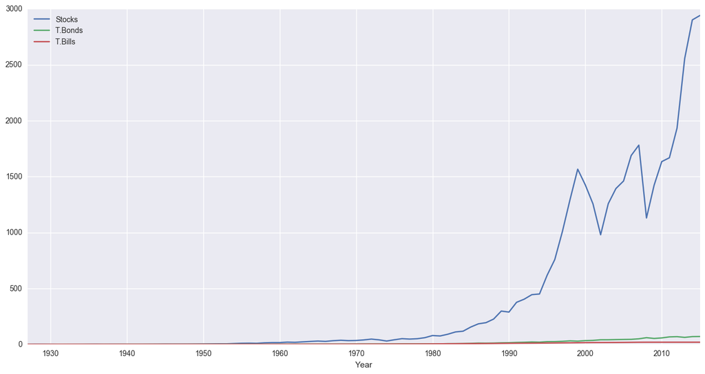

```python
us.plot();
```

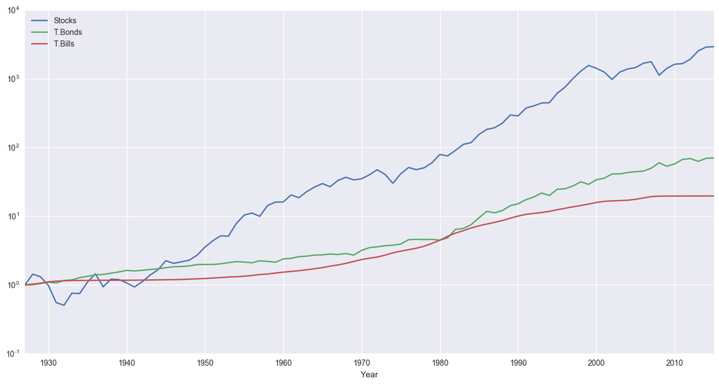

```python
us.plot(logy=True);
```

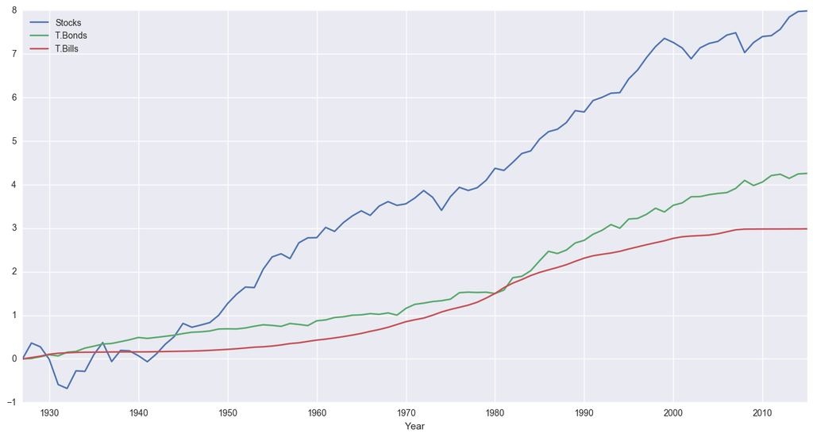

```python
np.log(us).plot();
```

## Neper

The **neper** (unit symbol **Np**) is a logarithmic unit for ratios of measurements of physical field and power quantities, such as gain and loss of electronic signals. The unit's name is derived from the name of John Napier, the inventor of logarithms.

Like the decibel, the neper is a unit in a logarithmic scale. While the bel uses the decadic (base-10) logarithm to compute ratios, the neper uses the natural logarithm, based on Euler's number (e ≈ 2.71828). The value of a ratio in nepers is given by

$$ L_{\rm {Np}}=\ln {\frac {x_{1}}{x_{2}}}=\ln x_{1}-\ln x_{2}.$$

where $ x_{1} $ and $ x_{2} $ are the values of interest (amplitudes), and $\ln$ is the natural logarithm.

## Decibels

When referring to measurements of power quantities, a ratio can be expressed as a level in **decibels** by evaluating ten times the base-10 logarithm of the ratio of the measured quantity to reference value. Thus, the ratio of $P$ (measured power) to $P_{0}$ (reference power) is represented by $L_{P}$, that ratio expressed in decibels,[17] which is calculated using the formula:[2]

$$ L_{P}=10\log _{10}\!\left({\frac {P}{P_{0}}}\right)\!~\mathrm {dB} $$

The base-10 logarithm of the ratio of the two power levels is the number of **bels**. The number of decibels is ten times the number of bels (equivalently, a decibel is one-tenth of a bel).

## centiBils

When referring to measurements of **asset prices**, a ratio can be expressed as a level in **centibils** by evaluating **one hundred times** the **base-2 logarithm** of the ratio of the **measured price** to **reference price**. Thus, the ratio of $S$ (measured price) to $S_{0}$ (reference price) is represented by $L_{S}$, that ratio expressed in centibils, which is calculated using the formula:

$$ L_{S}=100\log _{2}\!\left({\frac {S}{S_{0}}}\right)\!~\mathrm {cB} $$

The base-2 logarithm of the ratio of the two prices is the number of **bils**. The number of centibils is one hundred times the number of bils (equivalently, a centibil is one-hundreth of a bil).

### Conversions

$$ 1 + r = \frac{S}{S_0} $$$$ \implies L_{S}=100\log _{2}\!\left(1 + r\right)\!~\mathrm {cB} $$$$ \implies L_{S}=\frac{100}{\ln 2}\ln\!\left(1 + r\right)\!~\mathrm {cB} $$

and

$$ 1 + r = 2^{ \left( \frac{L_{S}}{100} \right) } $$$$ \implies r = \exp \!\left( \ln 2 \frac{L_{S}}{100} \right) - 1 $$$$ \implies r = \exp \!\left( \frac{\ln 2}{100} L_{S} \right) - 1 $$

```python
CENTIBIL_FACTOR = 100/np.log(2)

def ret2cb(ret):
    return CENTIBIL_FACTOR*np.log1p(ret)

def cb2ret(cb):
    return np.expm1(cb/CENTIBIL_FACTOR)

def idx2cb(idx):
    return CENTIBIL_FACTOR*np.log(idx)

def cb2idx(cb):
    return np.exp(cb/CENTIBIL_FACTOR)
```

### Standard Percentage Returns

```python
standard_returns
```

|  | Percentage Return | centiBils Return |
| --- | --- | --- |
| 0 | -100.00% | -inf cB |
| 1 | -50.00% | -100.00 cB |
| 2 | -25.00% | -41.50 cB |
| 3 | -20.00% | -32.19 cB |
| 4 | -10.00% | -15.20 cB |
| 5 | -1.00% | -1.45 cB |
| 6 | -0.01% | -0.01 cB |
| 7 | 0.00% | 0.00 cB |
| 8 | 0.01% | 0.01 cB |
| 9 | 1.00% | 1.44 cB |
| 10 | 10.00% | 13.75 cB |
| 11 | 20.00% | 26.30 cB |
| 12 | 25.00% | 32.19 cB |
| 13 | 50.00% | 58.50 cB |
| 14 | 100.00% | 100.00 cB |

### Standard centiBil Values

```python
standard_centibils
```

|  | Percentage Return | centiBils Return |
| --- | --- | --- |
| 0 | -50.00% | -100.00 cB |
| 1 | -29.29% | -50.00 cB |
| 2 | -15.91% | -25.00 cB |
| 3 | -12.94% | -20.00 cB |
| 4 | -6.70% | -10.00 cB |
| 5 | -0.69% | -1.00 cB |
| 6 | -0.01% | -0.01 cB |
| 7 | 0.00% | 0.00 cB |
| 8 | 0.01% | 0.01 cB |
| 9 | 0.70% | 1.00 cB |
| 10 | 7.18% | 10.00 cB |
| 11 | 14.87% | 20.00 cB |
| 12 | 18.92% | 25.00 cB |
| 13 | 41.42% | 50.00 cB |
| 14 | 100.00% | 100.00 cB |

## Applications

### centiBils are symmetric!

### centiBils are additive!

```python
tbl
```

| Percentage Return | centiBils Return |
| --- | --- |
| -30.00% | -51.46 cB |
| 40.00% | 48.54 cB |

### centiBils averages are representative of growth rates!

```python
to_html_perc(calc_metrics(returns))
```

|  | S&P 500 | 10-year T. Bond | 3-month T.Bill | S&P 2X |
| --- | --- | --- | --- | --- |
| Mean | 11.41% | 5.23% | 3.49% | 11.41% |
| Std Dev. | 19.82% | 7.79% | 3.07% | 39.63% |
| CAGR | 9.50% | 4.96% | 3.45% | -1.22% |

```python
cb_metrics
```

|  | S&P 500 | 10-year T. Bond | 3-month T.Bill | S&P 2X |
| --- | --- | --- | --- | --- |
| Mean | 13.09 cB | 6.98 cB | 4.89 cB | -1.77 cB |
| Std Dev. | 27.83 cB | 10.40 cB | 4.22 cB | 97.00 cB |

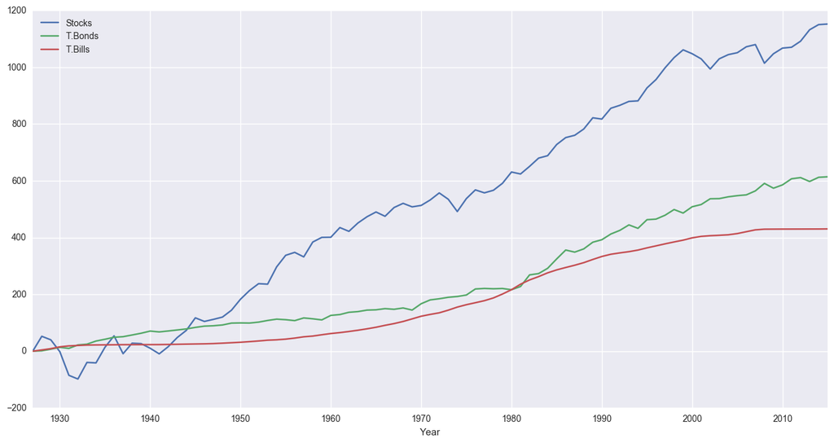

```python
idx2cb(us).plot();
```

## Conclusion

[figure not shown]

### Some times changing what's on the axes can lead to new insights!

# Questions?

[figure not shown]

## Thank you!

```python
%%HTML
<video controls>
  <source src="media/I_ve_got_bills.mp4" type="video/mp4">
</video>
```

[video not shown]